# Caribou RSF 4.0

Tyler Muhly

28/02/2020

## Introduction

Here I develop statistical models to quantify the effect of forestry disturbance on caribou distribution. The intent is to use the models to indicate the influence of current and potential future forestry development on caribou use of habitat. Tne model will be implemented as a module (i.e., rsfCLUS) in the caribou and land use simulator (CLUS). Seperate models were fit for the four caribou designatable units (DUs) in British Columbia (BC): DU6, boreal; DU7, northern mountain; DU8, central mountain; and DU9, southern mountain, as defined by the [Committee on the Status of Endangered Wildlife in Canada (COSEWIC)](https://www.registrelep-sararegistry.gc.ca/default.asp?lang=En&n=E6271D78-1&offset=2#_01_4). DUs were modeled independently, as they are intended to represent groups of caribou with unique ecological characteristics, and potentially different responses to forestry disturbance.

I use a resource selection function (RSF) framework to develop the statistical models ( [Boyce et al. 1999](https://www.sciencedirect.com/science/article/pii/S0169534799015931), [Johnson et al. 2006](https://wildlife.onlinelibrary.wiley.com/doi/pdf/10.2193/0022-541X%282006%2970%5B347%3ARSFBOU%5D2.0.CO%3B2)). This framework uses a logit regression model to calculate the relationship between caribou occurence and habitat ‘resources’ measured using spatial data. Here I am only considering the effect of forestry disturbance ‘resources’, i.e., cutblocks and roads, on caribou occurrence. This approach simplifies and focuses the RSF onto modeling a statistical relationship between caribou distribution and forestry disturbance that is generalizable across a caribou DU, and is not designed to accurately identify other habitat features that influence caribou distribution. The theoretical basis for this approach is that forestry disturbance has a significant influence on caribou distribution, regardless of other habitat features. Indeed, cutblocks and linear features from forestry have routinely been shown to influence caribou distribution (e.g., [Courbin et al. 2009](https://link.springer.com/article/10.1007/s10980-009-9389-x), [DeCesare et al. 2012](https://esajournals.onlinelibrary.wiley.com/doi/abs/10.1890/11-1610.1), [Mumma et al. 2018](https://www.sciencedirect.com/science/article/pii/S0006320718307225)) and survival ( [Wittmer et al. 2007](https://besjournals.onlinelibrary.wiley.com/doi/full/10.1111/j.1365-2656.2007.01220.x), [Johnson et al. 2015](https://www.sciencedirect.com/science/article/pii/S0006320715001160)).

The caribou-forestry disturbance models (CFDMs) created here can be used as a spatial indicator of current and simulated future effects of forestry activity on caribou habitat quality. For example, the sum of CFDM outputs can be calculated within caribou herd ranges or critical habitat types, and changes in the sum value over time can be used to indicate changes in forestry disturbance influencing caribou habitat quality.

## Methods

I calculated the CFDMs using generalized linear mixed models (GLMMs) with a logit link, using the [glmer function](https://www.rdocumentation.org/packages/lme4/versions/1.1-21/topics/glmer) from the [lme4](https://cran.r-project.org/web/packages/lme4/lme4.pdf) package in [program R](https://www.r-project.org/). I fit the model using caribou location data collected from telemetry collars placed on a sample of caribou (n = 468 animals, 507,987 locations) from across BC, between 2008 to 2018. These data were compiled from the government of BC’s [Species Inventory (SPI) database](https://www2.gov.bc.ca/gov/content/environment/plants-animals-ecosystems/wildlife/wildlife-data-information/search-for-wildlife-data-information), [BC Oil and Gas Research and Innovation Society (OGRIS) data](http://www.bcogris.ca/boreal-caribou-home), and data from regional wildlife biologists in the BC government that was not yet entered into these databases. These data specified the locations on the landscape that were ‘used’ by caribou (*sensu* [Boyce et al. 1999](https://www.sciencedirect.com/science/article/pii/S0169534799015931)), i.e., the 1’s in the binomial distribution of the GLMMs dependent variable. I had no capture data for these animals, but it is likely the majority of the animals sampled were adult females, as the focus of caribou monitoring in BC is on measuring survival of adult females and the recruitment of their calves. Data was collected using a wide variety of telemetry collar technologies (e.g., GPS, ARGOS) and suppliers (e.g., Lotek, ATS, Telonics), and with varying location fix rates (e.g., 2 hours to 12 hours). All data were collected under provincial government permits and following provincial animal care and handling protocols.

I sampled locations ‘available’ to caribou, i.e., the 0’s in the binomial distribution of the GLMMs dependent variable, by calculating the seasonal home ranges of individual animals and randomly sampling locations within these areas. I calculated home ranges using the kernelUD function in the adehabitatHR ( [Calenge et al. 2011](https://cran.r-project.org/web/packages/adehabitatHR/vignettes/adehabitatHR.pdf)) package of Program R. I varied the smoothing parameter (*h*) in the bivariate normal kernel algorithm and visually assesed the fit of 95% kernel polygons to the telemetry data. I selected the polygons with an *h* = 500, as they appeared to best fit the data ( [Hemson et al. 2005](https://besjournals.onlinelibrary.wiley.com/doi/full/10.1111/j.1365-2656.2005.00944.x), [Calenge et al. 2011](https://cran.r-project.org/web/packages/adehabitatHR/vignettes/adehabitatHR.pdf)), i.e., they reasonably formed contiguous habitat areas (i.e., connected polygons) without including large extents greater than 1km from telemetry locations (Fig. 1). Animals with less than 50 locations in a season were removed from the analysis, as this is considered the minimum number of locations needed to calculate a home range using a kernel density algorithm ( [Seaman et al. 1999](https://www.jstor.org/stable/3802664?seq=1), [Kernohan et al. 2001](https://www.sciencedirect.com/science/article/pii/B9780124977815500062)). Seasons were defined as: summer (15-May to 31-Oct), early winter (01-Nov to 15-Jan) and late winter (16-Jan to 14-May), based on a review of the literature on variation in the seasonal distribution of caribou in British Columbia. Within each seasonal home range, I randomly sampled 1,000 locations.

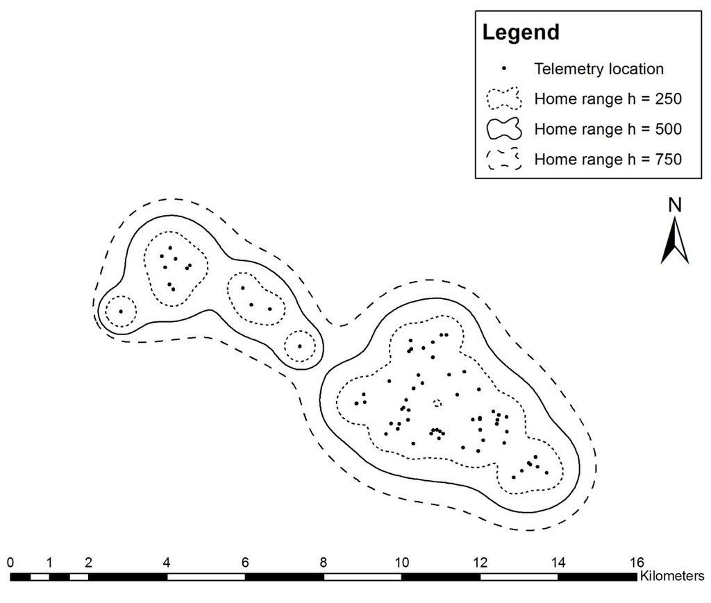

Figure 1. Example of different smoothing factors (*h*) used to calculate caribou home ranges with a kernel density algorithm.

I estimated the distance of ‘used’ and ‘available’ caribou locations to the nearest resource road and cutblock. Cutblock locations were estimated using the [consolidated cutblocks](https://catalogue.data.gov.bc.ca/dataset/harvested-areas-of-bc-consolidated-cutblocks-) data compiled by the BC government. Road locations were estimated using data compiled to support the [British Columbia Cumulative Effects Framework](https://www2.gov.bc.ca/gov/content/environment/natural-resource-stewardship/cumulative-effects-framework). This data is not accessible to the public via a webpage, but it is not private or proprietary, and thus can be requested from the cumulative effects program. The roads data classifies roads into various types. Our focus was on roads developed specifically for resource extraction (particularly forestry), thus, we classified all unpaved road types as ‘resource roads’ and estimated caribou distance to these types. Cutblock and roads data were rasterized at a 1ha resolution, and the Euclidean distance of each raster pixel to a cutblock or resource road in the pixel was calculated in ArcGIS and attributed to corresponding ‘used’ and ‘available’ caribou locations.

Clearly, other habitat characteristics besides forestry disturbance influence caribou distribution (e.g., terrain and vegetation, as they relate to food and predation risk; see for example, [Terry et al. 2000](https://besjournals.onlinelibrary.wiley.com/doi/full/10.1046/j.1365-2664.2000.00523.x), [Apps et al. 2001](http://www.env.gov.bc.ca/cariboo/env_stewardship/wildlife/inventory/caribou/northcar/hmi/hsi06-01.pdf); [Johnson et al. 2004](https://besjournals.onlinelibrary.wiley.com/doi/10.1111/j.0021-8901.2004.00899.x); [Apps & McLellan 2006](https://www.sciencedirect.com/science/article/pii/S000632070500546X)), and I initially attempted to fit models with some of these other factors. However, this led to the development of complex habitat models that did not improve my ability to estimate the effects of disturbance on caribou distribution. Instead, model building and interpretation became challenging due to the difficulty in fitting a generalizable model to unique habitats across a DU. However, I did evaluate correlation between the forestry disturbance factors modeled here and other habitat features measured using spatial data (e.g., elevation, slope, forest stand characteristics) to ensure they were not completely confounded. Specifically, I tested for correlations using a Spearman correlation, ensuring correlation coefficients between covariates were less than 0.7, and by evaluating variance inflation factors (VIFs) in generalized linear models (GLMs), and ensuring VIFs were less than 10 ( [DeCesare et al. 2012](https://esajournals.onlinelibrary.wiley.com/doi/abs/10.1890/11-1610.1)). This provided reassurance that distance to cublocks and roads were not confounded with each other or other habitat features potentially driving caribou distribution.

## Results

### DU6

**Table 1. Number of Animals and Telemetry Locations Sampled by Caribou Herd in DU6 (Boreal).**

| Herd | Animals | Locations |
| --- | --- | --- |
| Calendar | 33 | 23115 |
| Chinchaga | 43 | 29685 |
| Maxhamish | 33 | 21158 |
| Parker | 7 | 7751 |
| Prophet | 5 | 4390 |
| Snake-Sahtaneh | 39 | 28452 |

#### Herd-Level Effect of Forestry on Caribou Distribution

There were some small differences in herd response to resource roads in DU6 (Fig. 2). For example, caribou in the Calendar, Chinchaga, Parker and Snake-Sahtaneh herds were further from roads then what was available on average in their home range. A random effect for distance to road was included in the GLMM to account for this variability.

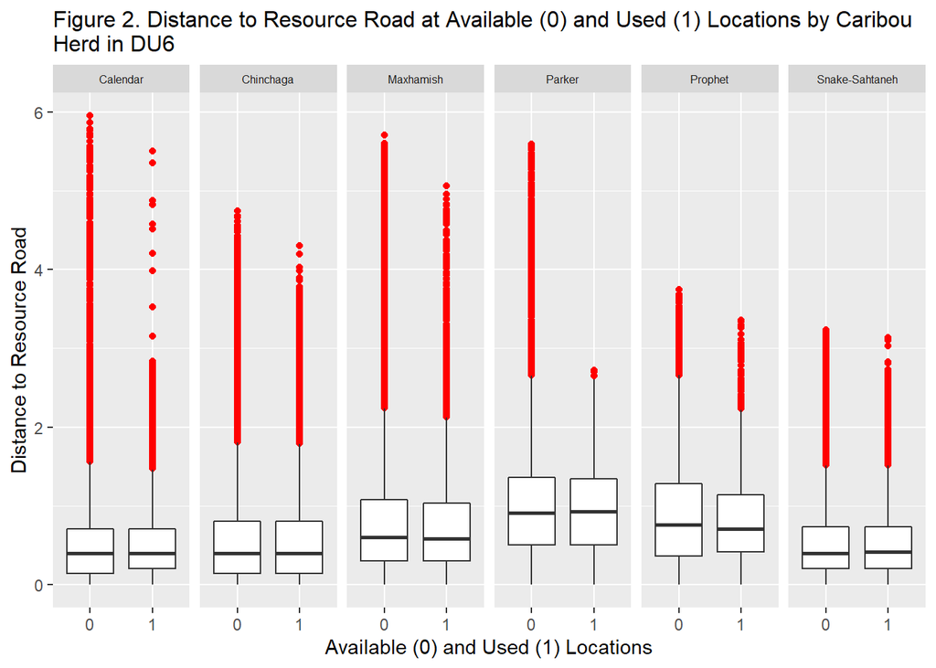

There was variability in caribou response to 1 to 4 year old cutblocks across herds in DU6 (Fig. 3). For example, caribou in the Chinchaga and Prohpet herds were closer to 1 to 4 year old cutblocks then what was available on average in their home range, whereas caribou in the Maxhamish, Parker and Snake-Sahtaneh were further from 1 to 4 year old cutblocks. A random effect for distance to 1 to 4 year old cutblocks was included in the GLMM to account for this variability.

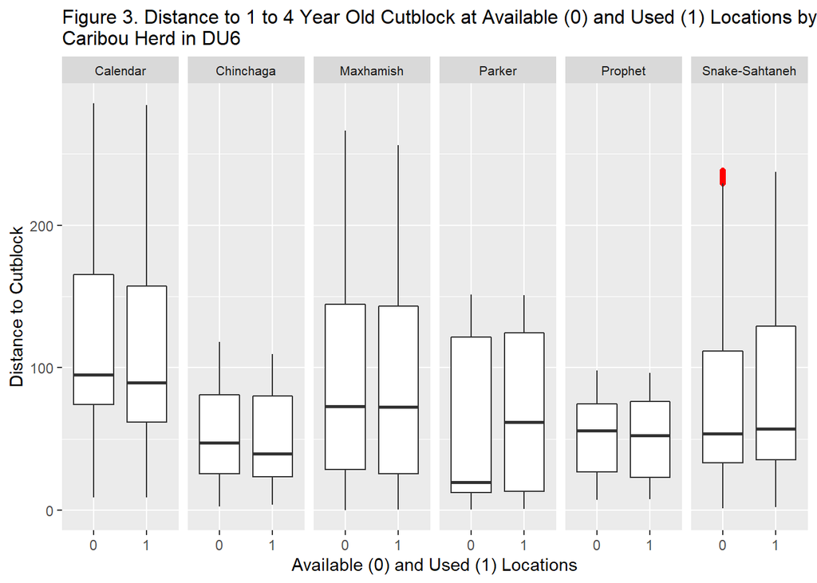

There was variability in caribou response to 5 to 9 year old cutblocks across herds in DU6 (Fig. 4). For example, caribou in the Calendar, Maxhamish and Prophet herds were closer to 5 to 9 year old cutblocks then what was available on average in their home range, compared to other herds. A random effect for distance to 5 to 9 year old cutblocks was included in the GLMM to account for this variability.

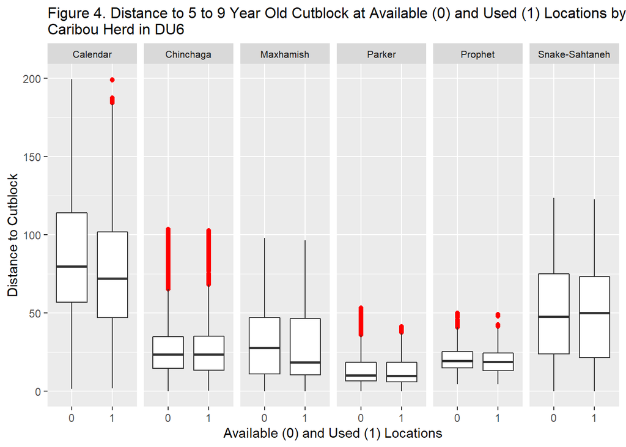

There was variability in caribou response to 10 to 40 year old cutblocks across herds in DU6 (Fig. 5). For example, caribou in the Maxhamish and Prophet herds were closer to 10 to 40 year old cutblocks then what was available on average in their home range, comapred to other herds. A random effect for distance to 10 to 40 year old cutblocks was included in the GLMM to account for this variability.

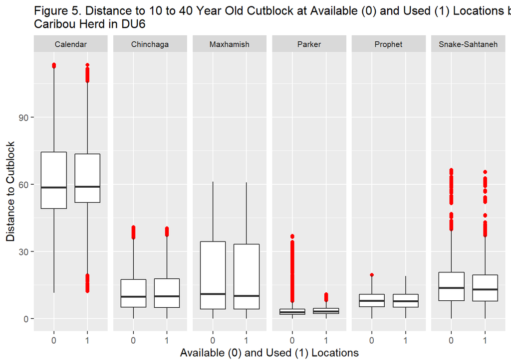

#### Caribou-Forestry Disturbance Model

```r
# model spec
model.lme4.du6.cut.rd <- glmer (pttype ~ distance_to_resource_road +
                                         distance_to_cut_1to4 +
                                         distance_to_cut_5to9 +
                                         distance_to_cut_10to40 +
                                        (distance_to_resource_road +
                                         distance_to_cut_1to4 +
                                         distance_to_cut_5to9 +
                                         distance_to_cut_10to40 || HERD_NAME) +
                                        (distance_to_resource_road +
                                         distance_to_cut_1to4 +
                                         distance_to_cut_5to9 +
                                         distance_to_cut_10to40 || animal_id),
                                      data = rsf.data.du6,
                                      family = binomial (link = "logit"),
                                      verbose = T)
# check residuals
binnedplot (fitted (model.lme4.du6.cut.rd),
             residuals(model.lme4.du6.cut.rd, type = "response"),
             nclass = NULL,
             xlab = "Expected Values",
             ylab = "Average residual",
             main = "DU6 Model Binned Residual Plot",
             cex.pts = 0.4,
             col.pts = 1,
             col.int = "red")
```

**Table 2. Fixed Effect Coefficients of the DU6 Caribou-Forestry Disturbance Model.**

| Coefficient | Coefficient.Estimate | Std..Error | z.value | p.value |
| --- | --- | --- | --- | --- |
| Intercept | -1.641 | 0.153 | -10.698 | 0.000 |
| Distance to Resource Road | 0.176 | 0.037 | 4.795 | 0.000 |
| Distance to Cutblock 1 to 4 years old | -0.005 | 0.002 | -2.016 | 0.044 |
| Distance to Cutblock 5 to 9 years old | -0.005 | 0.003 | -1.505 | 0.132 |
| Distance to Cutblock 10 to 40 years old | 0.020 | 0.011 | 1.912 | 0.056 |

Random effects in the DU6 model indicated that caribou consitently avoided roads across herds (Table 3, Fig. 6). There was consistency in caribou response to cutblocks across herds (Table 3, Fig. 7, Fig. 8, Fig. 9). Caribou consistently used areas near 1 to 9 year old cutblocks and avoided 10 to 40 year old cutblocks.

**Table 3. Random Effect Herd-Level Coefficients of the DU6 Caribou-Forestry Disturbance Model.**

| Herd | Intercept | Distance.to.Resource.Road | Distance.to.Cutblock.1.to.4.years.old | Distance.to.Cutblock.5.to.9.years.old | Distance.to.Cutblock.10.to.40.years.old |
| --- | --- | --- | --- | --- | --- |
| Calendar | -1.447 | 0.209 | -0.004 | -0.005 | 0.002 |
| Chinchaga | -1.637 | 0.218 | -0.005 | -0.005 | 0.004 |
| Maxhamish | -1.748 | 0.153 | -0.003 | -0.005 | 0.026 |
| Parker | -1.639 | 0.167 | -0.005 | -0.005 | 0.054 |
| Prophet | -1.579 | 0.156 | -0.005 | -0.005 | 0.013 |
| Snake-Sahtaneh | -1.792 | 0.146 | -0.006 | -0.005 | 0.020 |

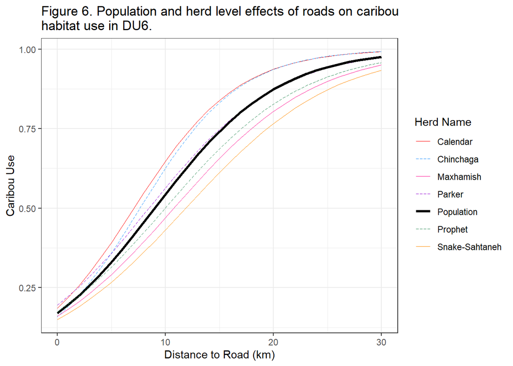

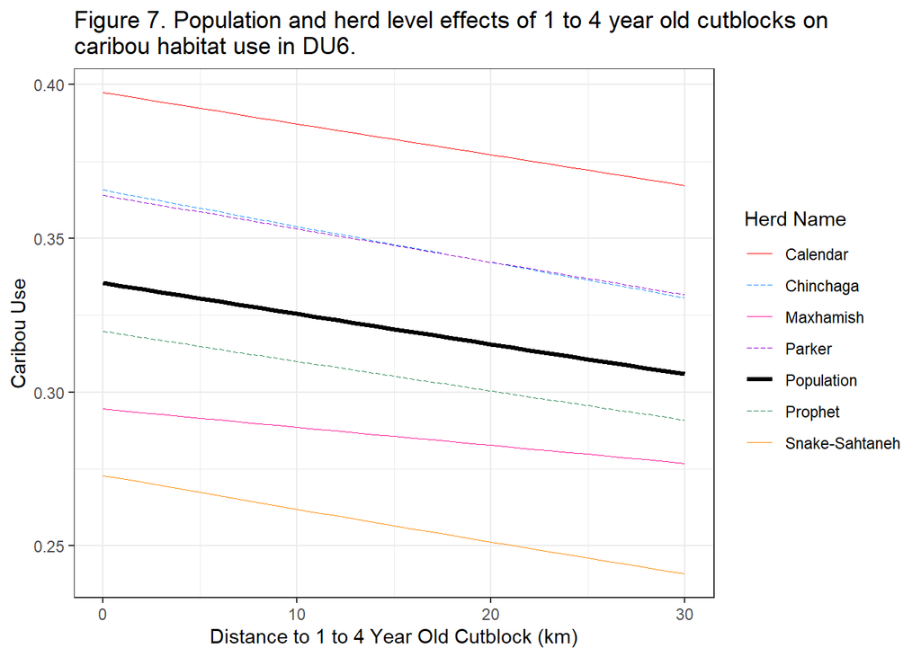

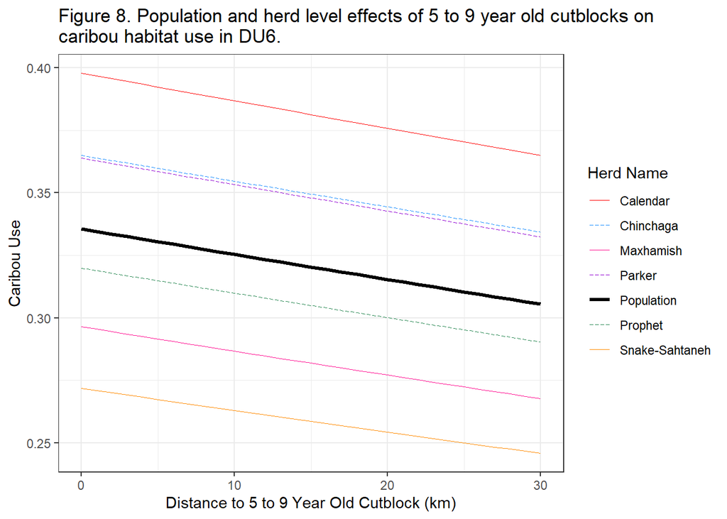

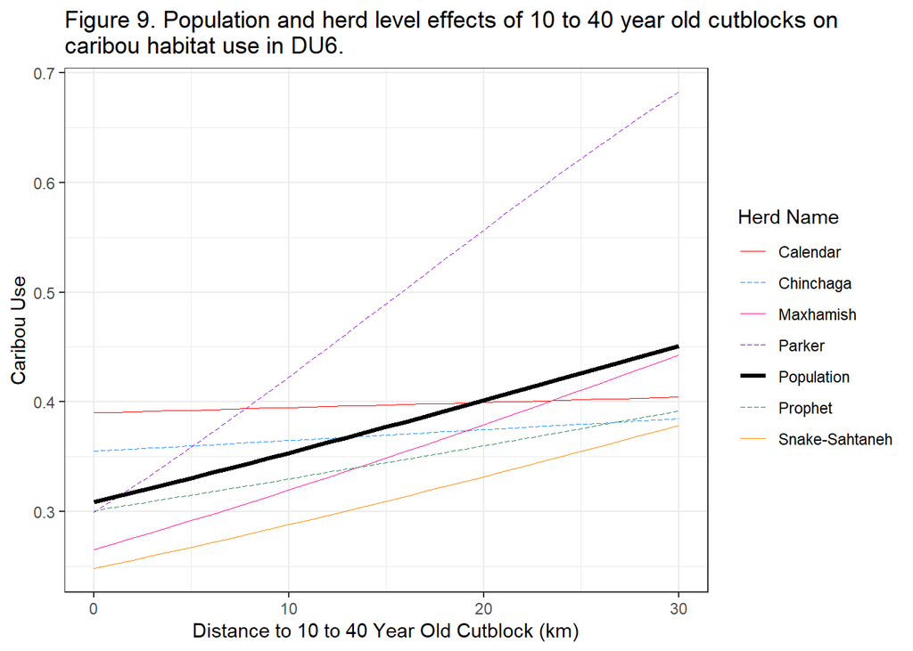

### DU7

In DU7, caribou location data was collected from 131 animals from the Charlotte Alplands, Chase, Finlay, Frog, Graham, Itcha-Ilgachuz, Muskwa, Pink Mountain, Rainbows, Spatsizi, Telkwa, Tsenaglode and Tweedsmuir herds. The number of animals sampled ranged from 1 to 35 per herd, and the number of telemetry locations ranged from 856 to 41,837 per herd (Table 4).

**Table 4. Number of Animals and Telemetry Locations Sampled by Caribou Herd in DU7.**

| Herd | Animals | Locations |
| --- | --- | --- |
| Charlotte Alplands | 4 | 3908 |
| Chase | 4 | 5827 |
| Finlay | 1 | 3020 |
| Frog | 4 | 8783 |
| Graham | 17 | 20473 |
| Itcha-Ilgachuz | 21 | 41837 |
| Muskwa | 19 | 10123 |
| Pink Mountain | 8 | 2599 |
| Rainbows | 9 | 8249 |
| Spatsizi | 5 | 12232 |
| Telkwa | 1 | 856 |
| Tsenaglode | 3 | 1381 |
| Tweedsmuir | 35 | 32131 |

#### Herd-Level Effect of Forestry on Caribou Distribution

There was variability in caribou response to resource roads across caribou herds in DU7 (Fig. 10). The majority of the herds tended to be further from roads, but caribou in the Frog and Finlay herds tended to be closer to roads then what was available on average in their home ranges. A random effect for distance to road was included in the GLMM to account for this variability.

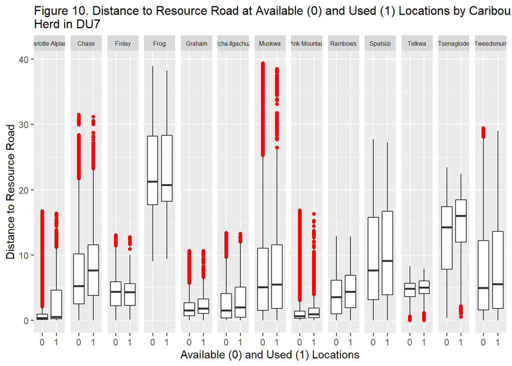

There was variability in caribou response to cutblocks 1 to 4 years old across herds in DU7 (Fig. 11). For example, caribou in the Charlotte Alplands, Finlay, Graham, Itcha-Ilgachuz, Muskwa, Pink Mountain, Spatsizi and Tsenaglode herds used areas further from 1 to 4 year old cutblocks, whereas caribou in the Chase, Rainbows and Tweedsmuir herds used areas closer to 1 to 4 year old cutblocks then what was available on average in their home range. A random effect for distance to 1 to 4 year old cutblocks was included in the GLMM to account for this variability.

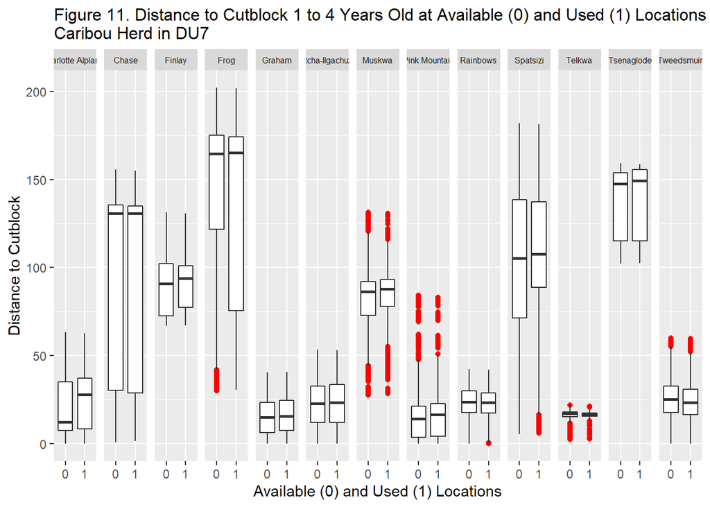

There was variability in caribou response to cutblocks 5 to 40 years old across herds in DU7 (Fig. 12). For example, caribou in the Charlotte Alplands, Chase, Finlay, Graham, Itcha-Ilgachuz, Muskwa, Pink Mountain, Rainbows, Spatsizi, Telkwa and Tweedsmuir herds used areas further from 5 to 40 year old cutblocks, whereas caribou in the Frog and Tsenaglode used areas closer to 5 to 40 year old cutblocks then what was available on average in their home range. A random effect for distance to 5 to 40 year old cutblocks was included in the GLMM to account for this variability.

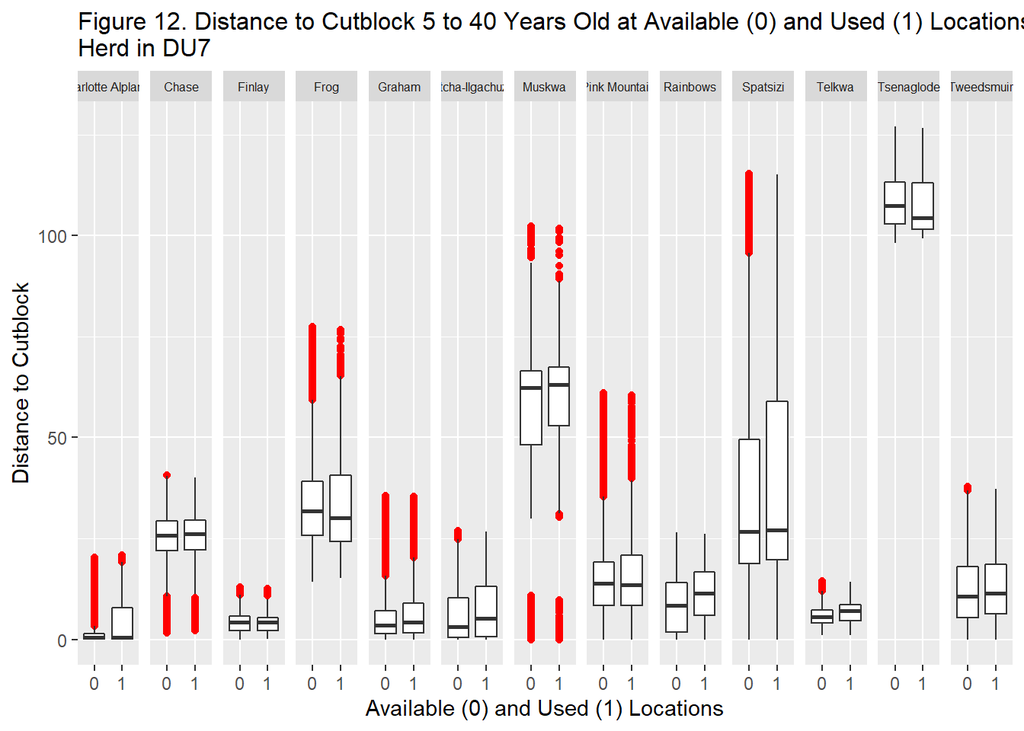

#### Caribou-Forestry Disturbance Model

There was a statistically significant (p-value < 0.05), negative population-level (fixed) effect of roads on caribou distribution (Table 5). Thus, on average, across caribou individuals and herds, caribou used areas further from roads (note that a positive coefficient is a negative effect, because the covariate is a ‘distance to’ metric). The model indicated a weak (non-significant), negative fixed effect of 5 to 40 year old cutblocks on caribou distribution, but a weak, positive effect of 1 to 4 year old cutblocks on caribou distribution.

```r
# model spec
model.lme4.du7.cut.rd <- glmer (pttype ~ distance_to_resource_road +
                                             distance_to_cut_1to4 +
                                             distance_to_cut_5to40 +
                                            (distance_to_resource_road +
                                             distance_to_cut_1to4 +
                                             distance_to_cut_5to40 || animal_id) +                                                               (distance_to_resource_road +
                                             distance_to_cut_1to4 +
                                             distance_to_cut_5to40 || HERD_NAME),
                                  data = rsf.data.du7,
                                  family = binomial (link = "logit"),
                                  verbose = T)
# check residuals
binnedplot (fitted (model.lme4.du7.cut.rd),
             residuals(model.lme4.du7.cut.rd, type = "response"),
             nclass = NULL,
             xlab = "Expected Values",
             ylab = "Average residual",
             main = "DU7 Model Binned Residual Plot",
             cex.pts = 0.4,
             col.pts = 1,
             col.int = "red")
```

**Table 5. Fixed Effect Coefficients of the DU7 Caribou-Forestry Disturbance Model.**

| Coefficient | Coefficient.Estimate | Std..Error | z.value | p.value |
| --- | --- | --- | --- | --- |
| Intercept | -1.486 | 0.211 | -7.054 | 0.000 |
| Distance to Resource Road | 0.059 | 0.021 | 2.777 | 0.005 |
| Distance to Cutblock 1 to 4 years old | -0.004 | 0.005 | -0.752 | 0.452 |
| Distance to Cutblock 5 to 40 years old | 0.008 | 0.010 | 0.776 | 0.438 |

Random effects in the DU7 model indicated that caribou generally avoided roads across herds, with the exception of the Rainbows herd, although there was variability in the strength of avoidance (Table 6, Fig. 13). There was variability in caribou response to cutblocks across herds and cutblock ages (Fig. 14, Fig. 15). Caribou in the Muskwa herd avoided cutblocks 1 to to 40 years old, caribou in the Chase, Graham, Itcha-Ilgachuz, Rainbows, Spatsizi, Telkwa and Tweedsmuir herds used cutblocks 1 to 4 years old, but avoided cutblocks 5 to to 40 years old, caribou in the Charlotte-Alplands, Pink Mountain, and Tsenaglode herds avoided cutblocks 1 to 4 years old, but used cutblocks 5 to to 40 years old and caribou in the Finlay and Frog herds used cutblocks 1 to to 40 years old.

**Table 6. Random Effect Herd-Level Coefficients of the DU7 Caribou-Forestry Disturbance Model.**

| Herd | Intercept | Distance.to.Resource.Road | Distance.to.Cutblock.1.to.4.years.old | Distance.to.Cutblock.5.to.40.years.old |
| --- | --- | --- | --- | --- |
| Charlotte Alplands | -0.994 | 0.199 | 0.003 | -0.040 |
| Chase | -1.214 | 0.049 | -0.003 | 0.004 |
| Finlay | -0.835 | 0.020 | -0.004 | -0.010 |
| Frog | -1.231 | 0.025 | -0.001 | -0.009 |
| Graham | -1.695 | 0.127 | -0.020 | 0.018 |
| Itcha-Ilgachuz | -0.860 | 0.029 | -0.016 | 0.015 |
| Muskwa | -3.014 | 0.017 | 0.004 | 0.011 |
| Pink Mountain | -2.452 | 0.130 | 0.018 | -0.025 |
| Rainbows | -0.694 | -0.006 | -0.002 | 0.064 |
| Spatsizi | -1.778 | 0.031 | -0.003 | 0.018 |
| Telkwa | -1.612 | 0.094 | -0.009 | 0.049 |
| Tsenaglode | -1.410 | 0.040 | 0.001 | -0.004 |
| Tweedsmuir | -1.511 | 0.009 | -0.015 | 0.011 |

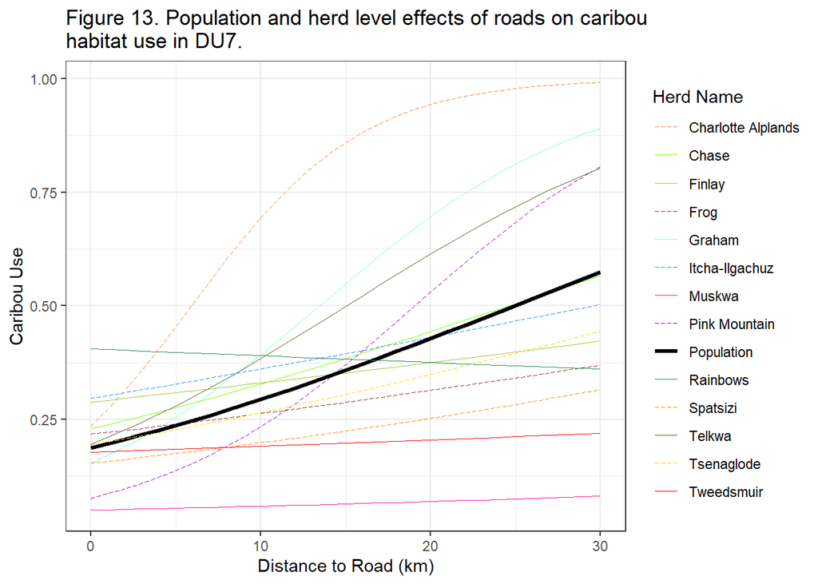

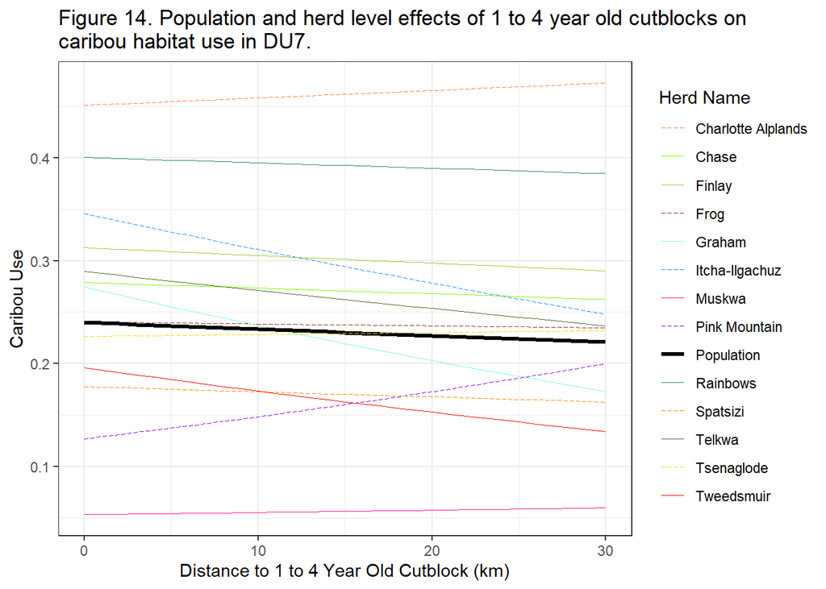

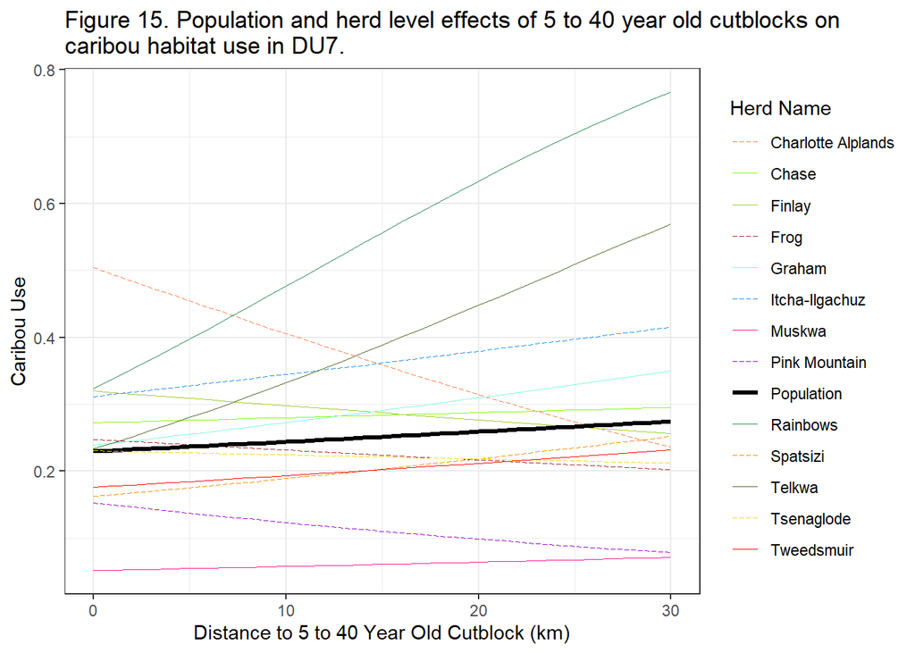

### DU8

In DU8, caribou location data was collected from 152 animals from the Burnt Pine, Kennedy Siding, Moberly, Narraway, Quintette and Scott herds. The number of animals sampled per herd ranged from 8 to 57 and the number of telemetry locations per herd ranged from 5,414 to 65,431 per herd (Table 7).

**Table 7. Number of Animals and Telemetry Locations Sampled by Caribou Herd in DU8.**

| Herd | Animals | Locations |
| --- | --- | --- |
| Burnt Pine | 16 | 5414 |
| Kennedy Siding | 38 | 31502 |
| Moberly | 14 | 13946 |
| Narraway | 19 | 11571 |
| Quintette | 57 | 65431 |
| Scott | 8 | 10164 |

#### Herd-Level Effect of Forestry on Caribou Distribution

There was variability in caribou response to resource roads across caribou herds in DU8 (Fig. 16). For example, caribou in the Burnt Pine, Kennedy Siding and Scott herds tended to be closer to roads, whereas caribou in the Moberly, Narraway and Quintette tended to be further from roads then what was available. A random effect for distance to road was included in the GLMM to account for this variability.

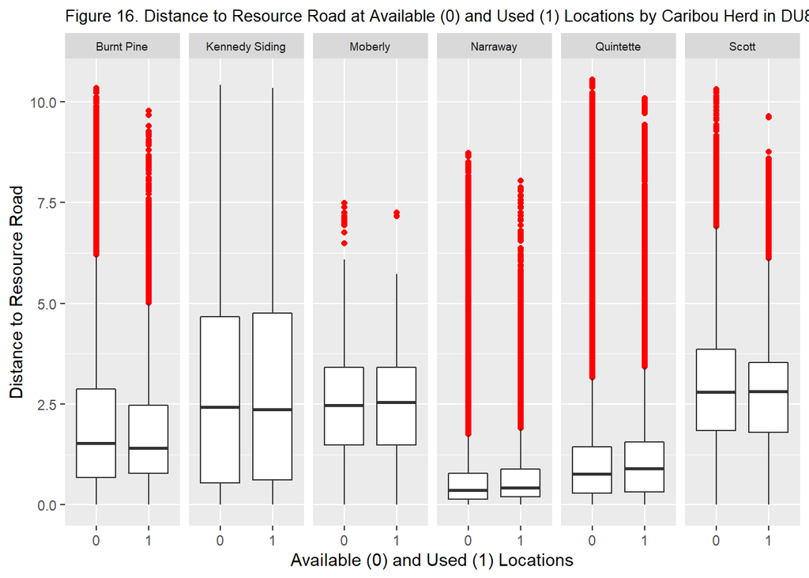

There was variability in caribou response to cutblocks 1 to 4 years old across herds in DU8 (Fig. 17). For example, caribou in the Burnt Pine, Kennedy Siding, Narraway and Quintette herds tended to use areas closer to 1 to 4 year old cutblocks, whereas caribou in the Moberly and Scott herds tended to be further from 1 to 4 year old cutblocks then what was available. A random effect for distance to cutblock 1 to 4 years old was included in the GLMM to account for this variability.

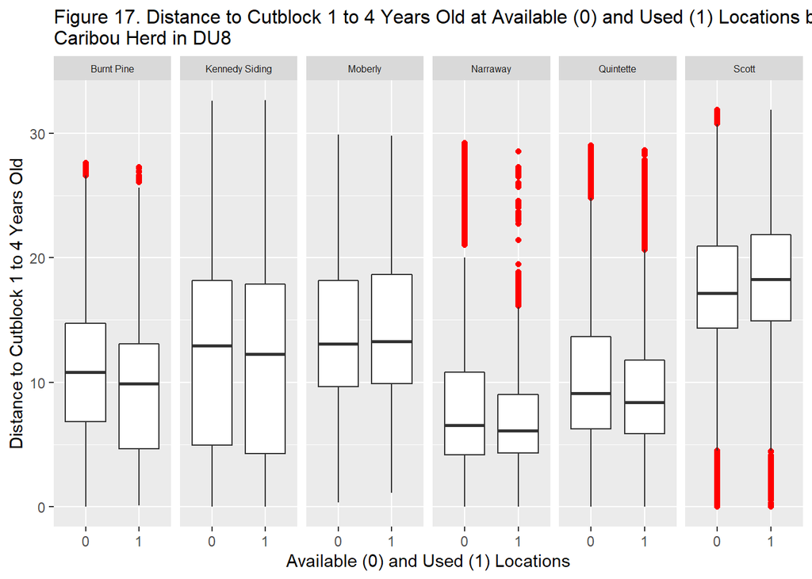

There was variability in caribou response to cutblocks 5 to 9 years old across herds in DU8 (Fig. 18). Most caribou herds tended to use areas closer to 5 to 9 year old cutblocks, with perhaps the exception being the Moberly herd. A random effect for distance to cutblock 5 to 9 years old was included in the GLMM to account for this variability.

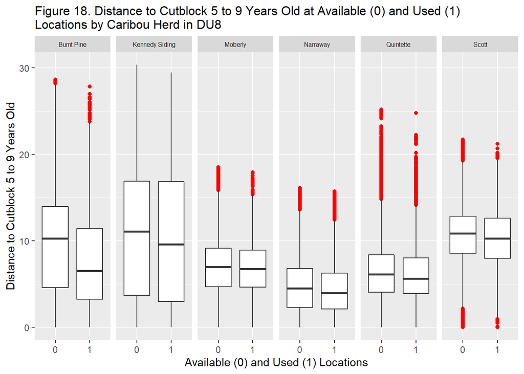

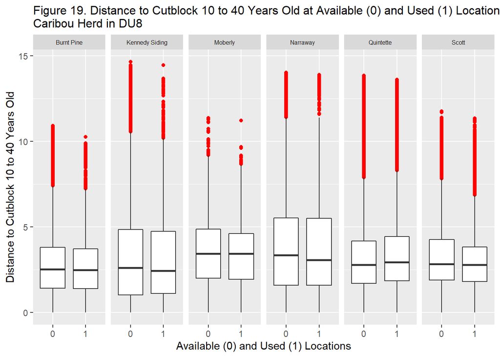

#### Caribou-Forestry Disturbance Model

There was a statistically significant (p-value < 0.05), negative fixed (population-level) effect of roads on caribou distribution (Table 8). There were generally positive fixed effects of cutblocks on caribou distribution. There was essentially no effect of 1 to 4 year old cutblocks on caribou distribution, a weak (p = 0.166) positive effect of 5 to 9 year old cutblocks, and a close to statistically significant (p-value = 0.07) positive effect of 10 to 40 year old cutblocks on caribou distribution.

```r
# model spec
model.lme4.du8.cut.rd <- glmer (pttype ~ distance_to_resource_road +
                                         distance_to_cut_1to4 +
                                         distance_to_cut_5to9 +
                                         distance_to_cut_10to40 +
                                        (distance_to_resource_road +
                                         distance_to_cut_1to4 +
                                         distance_to_cut_5to9 +
                                         distance_to_cut_10to40 || animal_id) +                                                              (distance_to_resource_road +
                                         distance_to_cut_1to4 +
                                         distance_to_cut_5to9 +
                                         distance_to_cut_10to40 || HERD_NAME),
                                  data = rsf.data.du8,
                                  family = binomial (link = "logit"),
                                  verbose = T)
# check residuals
binnedplot (fitted (model.lme4.du8.cut.rd),
             residuals(model.lme4.du8.cut.rd, type = "response"),
             nclass = NULL,
             xlab = "Expected Values",
             ylab = "Average residual",
             main = "DU8 Model Binned Residual Plot",
             cex.pts = 0.4,
             col.pts = 1,
             col.int = "red")
```

**Table 8. Fixed Effect Coefficients of the DU8 Caribou-Forestry Disturbance Model.**

| Coefficient | Coefficient.Estimate | Std..Error | z.value | p.value |
| --- | --- | --- | --- | --- |
| Intercept | -1.675 | 0.094 | -17.865 | 0.000 |
| Distance to Resource Road | 0.143 | 0.049 | 2.895 | 0.004 |
| Distance to Cutblock 1 to 4 years old | -0.001 | 0.014 | -0.082 | 0.935 |
| Distance to Cutblock 5 to 9 years old | -0.025 | 0.018 | -1.386 | 0.166 |
| Distance to Cutblock 10 to 40 years old | -0.061 | 0.033 | -1.830 | 0.067 |

Random effects in the DU8 model indicated that caribou avoided roads consistently across herds, although there was variability in the strength of avoidance (Table 9, Fig. 20). Caribou in the Burnt Pine, Quintette and Scott avoided cutblocks 1 to 4 years old, whereas caribou in the Kennedy Siding, Moberly and Narraway used areas closer to cutblocks 1 to 4 years old (Fig. 21). Caribou in the Narraway and Quintette avoided cutblocks 5 to 9 years old, whereas caribou in the Burnt Pine, Kennedy Siding, Moberly and Scott used areas closer to cutblocks 5 to 9 years old (Fig. 22). All caribou herds selected cutblocks 10 to 40 years old (Fig. 23).

**Table 9. Random Effect Herd-Level Coefficients of the DU8 Caribou-Forestry Disturbance Model.**

| Herd | Intercept | Distance.to.Resource.Road | Distance.to.Cutblock.1.to.4.years.old | Distance.to.Cutblock.5.to.9.years.old | Distance.to.Cutblock.10.to.40.years.old |
| --- | --- | --- | --- | --- | --- |
| Burnt Pine | -1.758 | 0.044 | 0.046 | -0.089 | -0.017 |
| Kennedy Siding | -1.655 | 0.268 | -0.008 | -0.021 | -0.196 |
| Moberly | -1.672 | 0.183 | -0.003 | -0.056 | -0.095 |
| Narraway | -1.650 | 0.239 | -0.050 | 0.020 | -0.037 |
| Quintette | -1.851 | 0.115 | 0.008 | 0.010 | -0.009 |
| Scott | -1.459 | 0.005 | 0.001 | -0.014 | -0.006 |

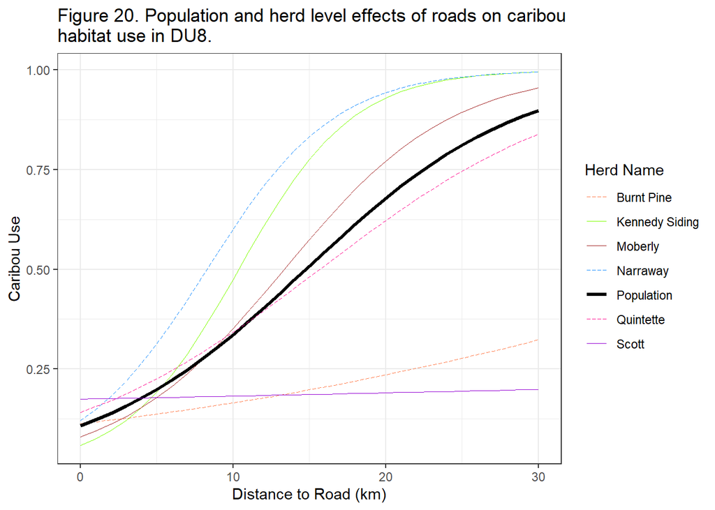

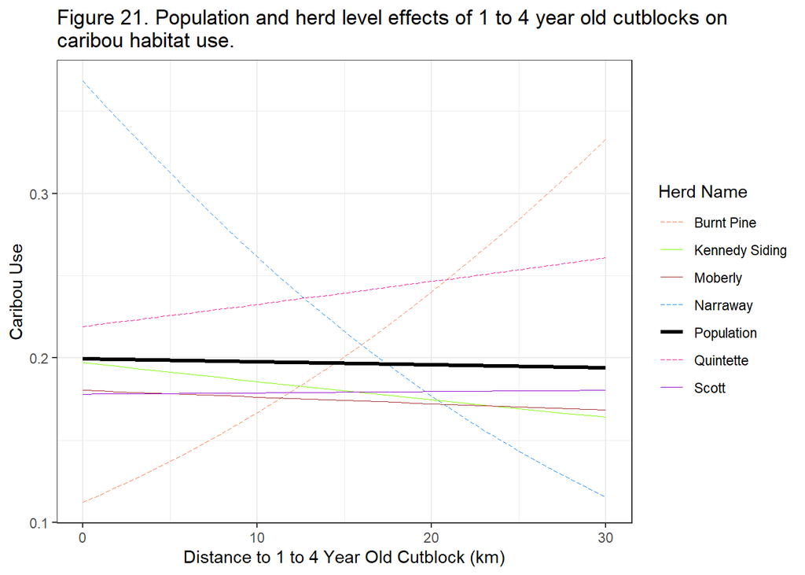

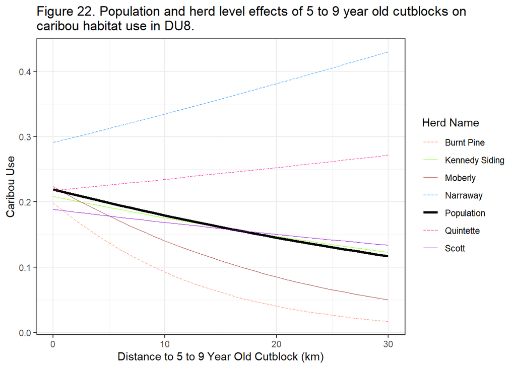

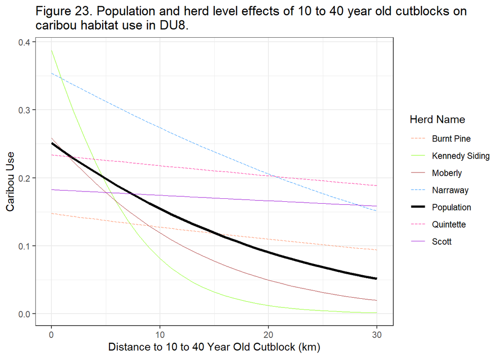

### DU9

In DU9, caribou location data was collected from 25 animals from the Hart Ranges, Nakusp and South Selkirks herds (Table 10). The number of animals sampled per herd ranged from 6 to 11 and the number of telemetry locations per herd ranged from 1,821 to 4,917 per herd.

**Table 10. Number of Animals and Telemetry Locations Sampled by Caribou Herd in DU9.**

| Herd | Animals | Locations |
| --- | --- | --- |
| Hart Ranges | 11 | 4917 |
| Nakusp | 8 | 1821 |
| South Selkirks | 6 | 2629 |

#### Herd-Level Effect of Forestry on Caribou Distribution

There was variability in caribou response to resource roads across caribou herds in DU9 (Fig. 24). For example, caribou in the Hart Ranges tended to be closer to roads, whereas caribou in the Nakusp and South Selkirks tended to be further from roads then what was available. A random effect for distance to road was included in the GLMM to account for this variability. Distance to resource road has highly correlated with distance to 10 to 40 year old cutblock ($\rho$ = 0.84), amd thus was not included in this analysis.

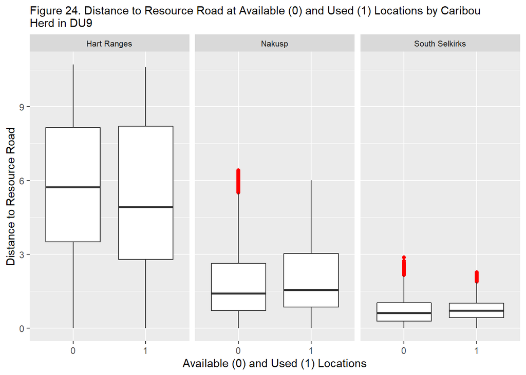

There was variability in caribou response to 1 to 4 year old cutblocks across herds in DU9 (Fig. 25). For example, caribou in the Hart Ranges and Nakusp herds tended to use areas further from 1 to 4 year old cutblocks, whereas caribou in the South Selkirks herd tended to be closer to cutblocks then what was available. A random effect for distance to 1 to 4 year old cutblock was included in the GLMM to account for this variability.

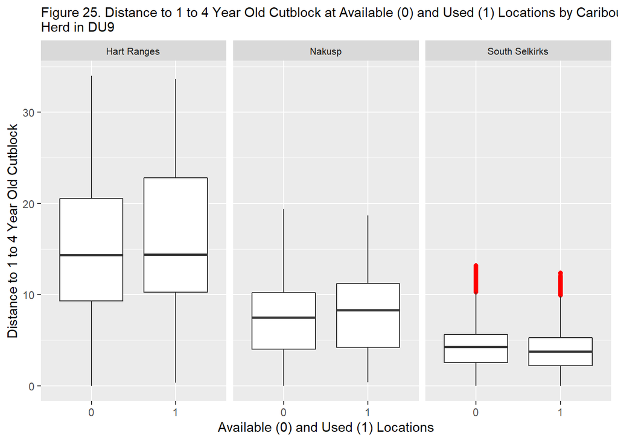

There was variability in caribou response to 5 to 9 year old cutblocks across herds in DU9 (Fig. 26). For example, caribou in the Hart Ranges and South Selkirks herds tended to use areas closer to 5 to 9 year old cutblocks, whereas caribou in the Nakusp herd tended to be further from cutblocks then what was available. A random effect for distance to 5 to 9 year old cutblock was included in the GLMM to account for this variability.

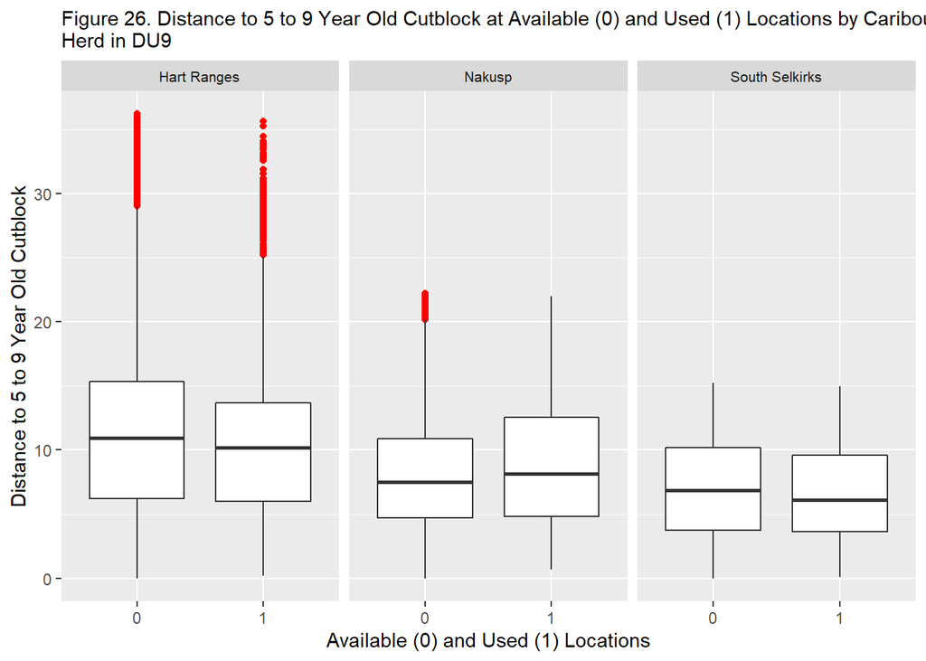

#### Caribou-Forestry Disturbance Model

The model included a statistically significant (p < 0.05), negative population-level (fixed) effect of roads on caribou distribution (Table 11). The population-level effect of 1 to 4 year old cutblocks was also negative, but weak and not statistically significant (p = 0.95). However, the effect of 5 to 9 year old cutblocks was positive, but not statistically significant (p = 0.06).

```r
# model spec
model.lme4.du9.cut.rd <- glmer (pttype ~ distance_to_resource_road + # roads highly correlated with 10 to 40 yo cutblocks
                                         distance_to_cut_1to4 +
                                         distance_to_cut_5to9 +
                                        (distance_to_resource_road +
                                         distance_to_cut_1to4 +
                                         distance_to_cut_5to9 || animal_id) +                                                                (distance_to_resource_road +
                                         distance_to_cut_1to4 +
                                         distance_to_cut_5to9 || HERD_NAME),
                                      data = rsf.data.du9,
                                      family = binomial (link = "logit"),
                                      verbose = T)
# check residuals
binnedplot (fitted (model.lme4.du9.cut.rd),
             residuals(model.lme4.du9.cut.rd, type = "response"),
             nclass = NULL,
             xlab = "Expected Values",
             ylab = "Average residual",
             main = "DU9 Model Binned Residual Plot",
             cex.pts = 0.4,
             col.pts = 1,
             col.int = "red")
```

**Table 11. Fixed Effect Coefficients of the DU9 Caribou-Forestry Disturbance Model.**

| Coefficient | Coefficient.Estimate | Std..Error | z.value | p.value |
| --- | --- | --- | --- | --- |
| Intercept | -2.410 | 0.252 | -9.575 | 0.000 |
| Distance to Resource Road | 0.150 | 0.074 | 2.021 | 0.043 |
| Distance to Cutblock 1 to 4 years old | 0.002 | 0.027 | 0.061 | 0.951 |
| Distance to Cutblock 5 to 9 years old | -0.026 | 0.014 | -1.865 | 0.062 |

Random effects in the DU9 model indicated that caribou avoided roads consistently across herds, although there was variability in the strength of avoidance (Table 12, Fig. 27). There was variability in use of areas close to 1 to 4 year cutblocks across herds, where caribou in the South Selkirks herd used areas closer to cutblocks and caribou in the Hart Ranges and Nakusp avoided cutblocks (Fig. 28). There was a consitent postivie response to cutblocks 5 to 9 years old across herds (Fig. 29).

**Table 12. Random Effect Herd-Level Coefficients of the DU9 Caribou-Forestry Disturbance Model.**

| Herd | Intercept | Distance.to.Resource.Road | Distance.to.Cutblock.1.to.4.years.old | Distance.to.Cutblock.5.to.9.years.old |
| --- | --- | --- | --- | --- |
| Hart Ranges | -2.164 | 0.055 | 0.007 | -0.026 |
| Nakusp | -2.735 | 0.102 | 0.040 | -0.026 |
| South Selkirks | -2.324 | 0.293 | -0.043 | -0.026 |

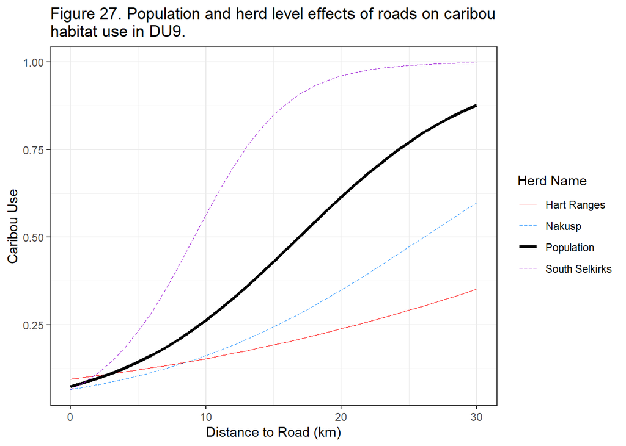

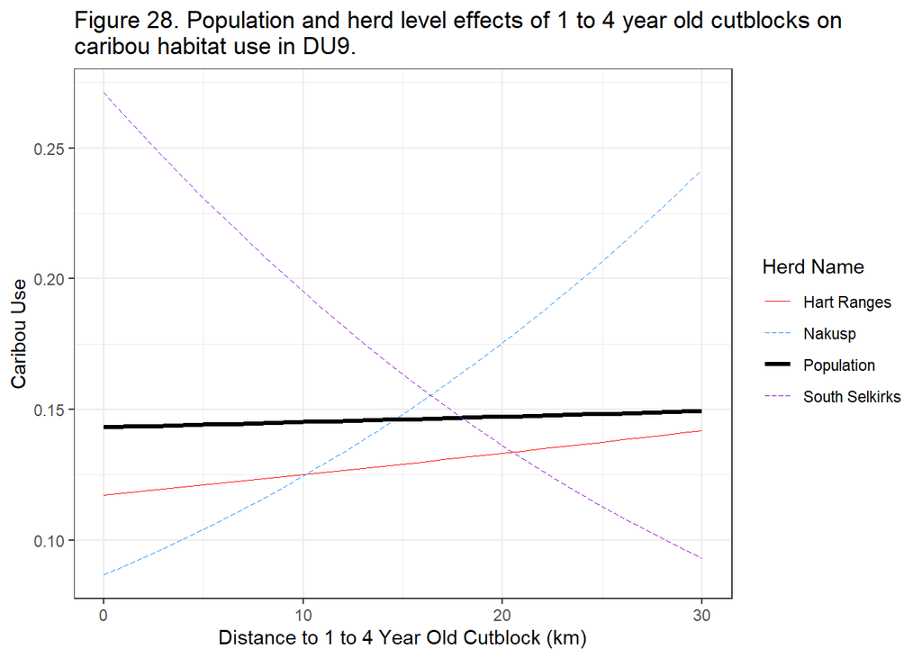

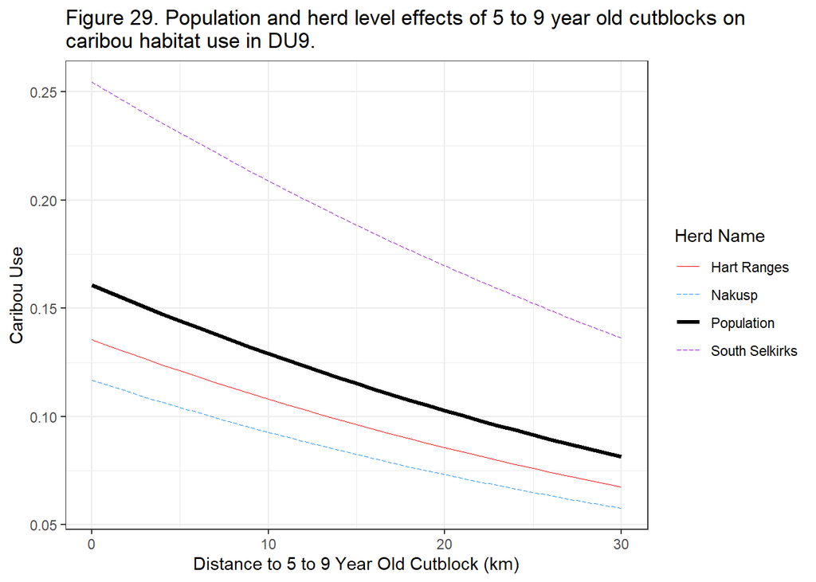

## Conclusions

Research has repeatedly shown that caribou are negatively influenced by forestry activity. This can include negative density effects, for example, on caribou survival ( [Wittmer et al. 2007](https://besjournals.onlinelibrary.wiley.com/doi/full/10.1111/j.1365-2656.2007.01220.x), [Johnson et al. 2015](https://www.sciencedirect.com/science/article/pii/S0006320715001160)), and behavioural effects, for example, on caribou distribution (e.g., [Courbin et al. 2009](https://link.springer.com/article/10.1007/s10980-009-9389-x), [DeCesare et al. 2012](https://esajournals.onlinelibrary.wiley.com/doi/abs/10.1890/11-1610.1), [Mumma et al. 2018](https://www.sciencedirect.com/science/article/pii/S0006320718307225)). Here we built on this evidence and developed a CFDM that empirically related forestry disturbance to caribou distribution. The model provides an indicator of forestry influences on caribou habitat, and thus can be linked to forestry simulator models, i.e., the caribou and land use simualtor (CLUS), to indicate spatial-temporal changes in caribou habitat quality from forestry.

Our CFDM showed a strong negative effect of resource roads on caribou distribution across DU’s. Roads are likely representative of many ecological effects of resource development on caribou. Roads can act as semi-permeable barriers to caribou, resulting in loss of functional habitat due to caribou avoidance of areas near roads ( [Dyer et al. 2001](https://www.jstor.org/stable/3803106), [Dyer et al. 2002](https://www.nrcresearchpress.com/doi/abs/10.1139/z02-060#.XkXNFTFKikw), [Wilson et al. 2016](https://www.sciencedirect.com/science/article/pii/S0006320715302147)). Caribou may also avoid roads to minimize predation risk ( [Dussault et al. 2012](https://royalsocietypublishing.org/doi/pdf/10.1098/rspb.2012.1700)), as predators such as wolves and bears may make use of these areas to hunt prey ( [Whittington et al. 2011](https://besjournals.onlinelibrary.wiley.com/doi/full/10.1111/j.1365-2664.2011.02043.x), [Latham et al 2011](https://esajournals.onlinelibrary.wiley.com/doi/abs/10.1890/11-0666.1)). The CFDM does not attempt to measure or disentangle the effects of these different ecological processes, but it is assumed that the negative relationship between caribou and roads is indicative of these processes.

In general, the CFDM indicated that the effect of cutblocks on caribou distribution was highly variable and weaker than the effect of roads. For example, caribou in the boreal (DU6), consistently selected cutblcosk 1 to 9 years old, but avoided cutblocks 10 to 40 years old, whereas the effect of 1 to 40 year old cutblocks varied across northern mountain (DU7) herds. Cutblocks can have a negative effect on caribou, as they provide forage for ungulates such as moose, thus supporting higher densities of ungulates and their predators, such as wolves, that then predate on caribou ( [Seip 1992](https://www.nrcresearchpress.com/doi/abs/10.1139/z92-206#.XkXfPTFKikw), [DeCesare et al. 2010](https://zslpublications.onlinelibrary.wiley.com/doi/full/10.1111/j.1469-1795.2009.00328.x), [Serrouya et al. 2017](https://peerj.com/articles/3736/?utm_source=TrendMD&utm_campaign=PeerJ_TrendMD_1&utm_medium=TrendMD)). However, there may be reasons why we detected a weak negative, or sometimes positive effect of cutblocks on caribou in some herds and DU’s. First, caribou may use cutblocks periodically throughout the year to access forage. Caribou will select for deciduous shrub species during summer foraging ( [Denryter et al. 2017](https://www.nrcresearchpress.com/doi/full/10.1139/cjz-2016-0114#.XkbFSjFKikw)), and these species tend to increase in cutblocks ( [Strong and Gates 2006](https://www.sciencedirect.com/science/article/pii/S0378112705006456)). Indeed, research in Quebec has found that caribou selected younger cutblocks, presumably because of their forage benefit ( [Dussault et al. 2012](https://royalsocietypublishing.org/doi/pdf/10.1098/rspb.2012.1700)). Second, the negative effect of cutblocks may occur at larger scales, outside of the home range. [DeCesare et al. 2012](https://esajournals.onlinelibrary.wiley.com/doi/abs/10.1890/11-1610.1) found that caribou avoided cutblocks at the range scale (i.e., caribou home ranges occurred in areas with fewer cutblocks), but not within their home ranges. This suggests the negative predation effect of cutblocks occurs at larger scales, that caribou are less likely to establish home ranges in areas with more cutblocks, perhaps because they are avoiding predation risk or they are unable to survive in those areas. Clearly, the effects of cutblocks on caribou distribution is more nuanced than roads, and the CFDM appears to represent these nuanced effects by representing a variable effect of cutblocks on caribou across herds and DUs.

The CFDM provides a framework for testing the effects of simulated future forestry activities on caribou. It includes random effects to account for individual and herd-level variability in caribou responses to cutblocks and roads, which provides a great deal of flexibility in estimating the effects of proposed future forestry activities on caribou. This model has been incorporated into the rsfCLUS module of the CLUS model.

Future work will focus on developing a similar model that accounts for the effects of roads and cutblocks at a larger scale, i.e., on the establishment of home rages by cariobu. In addition, we are relating these models to caribou population measures (e.g., trend) at a herd scale to assess their utility as indicators of caribou population responses to forestry disturbance.